# Machine Learning (CPS-863 / COS-623 / MAB-608)

> - Terceiro Trimestre de 2018
> - Professores: Edmundo de Souza e Silva, Daniel S. Menascé Rosa Leão
> - 2ª Lista de Exercícios (Graduação e Pós-Graduação)
> - **Lucas Lopes Felipe**

## Questão 1

> Consider a Normal distribution $\mathcal{N}$(μ, σ2) and N data samples ($\mathcal{D} = {x_1, x_2, . . . , x_N }$).

#### 1. What is the likelihood function $\mathcal{L}(\theta, \mathcal{D})$ in this case? Recall that *θ* is the parameter vector. How many elements vector *θ* has?

Dado que a distribuição do *dataset* é uma Normal, a *Probability Density Function* (PDF) é dada por:

$$ f(\mathcal{D} , \theta) = \frac{1}{\sigma \sqrt{2 \pi}} e^ \frac{ - \left(x_{i} - \mu \right)^2}{2 \sigma ^2} $$

Logo, a função de *Likelihood* é obtida através do produtório entre a Gaussiana de cada elemento do conjunto, pois considera-se que a probabilidades das amostras são indepentes entre si. A expressão pode ser representada da seguinte forma:

$$ \mathcal{L}(\theta , \mathcal{D}) = \prod_{i = 1}^{n} \frac{e^ \frac{ - \left(x_{i} - \mu \right)^2}{2 \sigma ^2}}{\sigma \sqrt{2 \pi}} $$

E também computacionalmente em *Python*:

```python
import math # Biblioteca para obter os valores de Pi e do Número de Euler

# Função Likelihood para uma distribuição Normal
def likelihood_normal(theta, dataset):
    L = 1
    for data in dataset:
        L *= normal(theta, data)
    return L

# Distribuição Guassiana (normal)
def normal(theta, data):
    mean = theta[0] # média
    stdv = theta[1] # desvio padrão
    return (math.e ** ((-(data - mean) ** 2) / (2 * (stdv ** 2)))) / (stdv * math.sqrt(2 * math.pi))
```

O vetor $ \theta $ contém os parâmetros do modelo, onde neste caso por ser uma distribuição normal, possui 2 elementos. São eles:

1. Média
2. Desvio Padão

#### 2. Show all the steps to obtain the MLE in this case. Compare your result and your proof with those in Theorem 4.1.1 of Murphy.

Se queremos obter o *Maximum Likelihood Estimate* precisamos descobrir os parâmetros do vetor $ \theta $ ($ \mu, \sigma^2 $) que produzam o maior *Likelihood* dentre qualquer outras combinação de valores possíveis.

Isso é o mesmo que descobrir o ponto onde a derivada da função equivale a 0, pois este é o topo da função, e logo, o valor que maxiza a mesma.

Porém, derivar a função *Likelihood* não é trivial, uma boa solução é derivar o logaritmo natural da função, pois além de transformar o log do produtório em um somatório dos logs (o que deixa o problema mais fácil), é uma função monotônica crescente, o que significa que possui o topo no mesmo ponto que a função original. O *Log-Likelihood* fica portanto da seguinte maneira:

$$ \mathcal{L}(\theta , \mathcal{D}) = \prod_{i = 1}^{n} \frac{e^ \frac{ - \left(x_{i} - \mu \right)^2}{2 \sigma ^2}}{\sigma \sqrt{2 \pi}} $$

$$ \ln (\mathcal{L}(\theta , \mathcal{D})) = \sum_{i = 1}^{n} \ln \left ( \frac{e^ \frac{ - \left(x_{i} - \mu \right)^2}{2 \sigma ^2}}{\sqrt{2 \pi \sigma^2}} \right ) $$

$$ \Rightarrow \sum_{i = 1}^{n} \ln \left ( \frac{1}{\sqrt{2 \pi \sigma^2}} \right ) + \ln \left ( e^ \frac{ - \left(x_{i} - \mu \right)^2}{2 \sigma ^2} \right ) $$

$$ \Rightarrow \sum_{i = 1}^{n} \ln \left ((2 \pi \sigma^2)^{-\frac{1}{2}} \right ) - \frac{(x_{i} - \mu)^2}{2 \sigma ^2} \ln(e) $$

$$ \Rightarrow \sum_{i = 1}^{n} -\frac{1}{2} \ln (2 \pi \sigma^2) - \frac{(x_{i} - \mu)^2}{2 \sigma ^2} $$

$$ \Rightarrow \sum_{i = 1}^{n} -\frac{1}{2} \ln (2 \pi) -\frac{1}{2} \ln (\sigma^2) - \frac{(x_{i} - \mu)^2}{2 \sigma ^2} $$

$$ \Rightarrow \sum_{i = 1}^{n} -\frac{1}{2} \ln (2 \pi) -\frac{2}{2} \ln (\sigma) - \frac{(x_{i} - \mu)^2}{2 \sigma ^2} $$

$$ \Rightarrow -\frac{n}{2} \ln (2 \pi) - n \, \ln (\sigma) - \sum_{i = 1}^{n} \frac{(x_{i} - \mu)^2}{2 \sigma ^2} $$

Agora que temos a o log da função, vamos derivar em função de $ \mu $ para descobrir o primeiro parâmetro:

$$ \frac{\partial}{\partial \mu} \ln(\mathcal{L}(\theta , \mathcal{D})) = -\frac{n}{2} \ln (2 \pi) - n \, \ln (\sigma) - \sum_{i = 1}^{n} \frac{(x_{i} - \mu)^2}{2 \sigma ^2} $$

$$ \Rightarrow 0 - 0 - \sum_{i = 1}^{n} \frac{2 (x_{i} - \mu)}{2 \sigma ^2} $$

$$ \Rightarrow \sum_{i = 1}^{n} \frac{(x_{i} - \mu)}{\sigma ^2} $$

$$ \Rightarrow \frac{1}{\sigma ^2} \sum_{i = 1}^{n} x_{i} - \mu $$

$$ \Rightarrow \frac{- n \, \mu}{\sigma ^2} \sum_{i = 1}^{n} x_{i} $$

Uma vez que temos a derivada da *Log-Likelihood*, para que encontremos o topo da função, devemos igualar a 0:

$$ \frac{\partial}{\partial \mu} \ln(\mathcal{L}(\theta , \mathcal{D})) = 0 $$

$$ \frac{- n \, \mu}{\sigma ^2} \sum_{i = 1}^{n} x_{i} = 0 $$

$$ n \, \mu = \sum_{i = 1}^{n} x_{i} $$

$$ \mu = \frac{\sum_{i = 1}^{n} x_{i}}{n} $$

Ou seja, o melhor valor para o pâmetro $ \mu $ é a média dos dados. Que pode ser representado pela função em Python:

```python
# Cálculo da média
def mean(data):
    total = 0
    for d in data:
        total += d
    return total / len(data)
```

Agora que encontramos o 1º parâmentro, vamos descobrir o segundo. Para isso, vamos derivar em função de $ \sigma$:

$$ \frac{\partial}{\partial \sigma} \ln(\mathcal{L}(\theta , \mathcal{D})) = -\frac{n}{2} \ln (2 \pi) - n \, \ln (\sigma) - \sum_{i = 1}^{n} \frac{(x_{i} - \mu)^2}{2 \sigma ^2} $$

$$ \Rightarrow 0 - \frac{n}{\sigma} - \sum_{i = 1}^{n} \frac{(x_{i} - \mu)^2}{2} \sigma ^{-2} $$

$$ \Rightarrow - \frac{n}{\sigma} - \sum_{i = 1}^{n} \frac{(x_{i} - \mu)^2}{2} (-2) \sigma ^{-3} $$

$$ \Rightarrow - \frac{n}{\sigma} + \sum_{i = 1}^{n} (x_{i} - \mu)^2 \sigma ^{-3} $$

$$ \Rightarrow - \frac{n}{\sigma} + \sum_{i = 1}^{n} \frac{(x_{i} - \mu)^2 }{\sigma^3} $$

$$ \Rightarrow - \frac{n}{\sigma} + \frac{1}{\sigma^3} \sum_{i = 1}^{n} (x_{i} - \mu)^2 $$

E novamente, igualar a 0, para encontrar o ponto em que a função está no topo:

$$ \frac{\partial}{\partial \sigma} \ln(\mathcal{L}(\theta , \mathcal{D})) = 0 $$

$$ n = \frac{1}{\sigma^2} \sum_{i = 1}^{n} (x_{i} - \mu)^2 $$

$$ n \, \sigma^2 = \sum_{i = 1}^{n} (x_{i} - \mu)^2 $$

```python
# Cálculo do Desvio Padrão
def stdv(data, mean):
    total = 0
    for d in data:
        total += (d - mean) ** 2
    return math.sqrt(total / (len(data) - 1))
```

## Questão 2

> For $ \mathcal{D} $ you are given 2 datasets: *D1* = `data-l2-p-1a.txt` and *D2* = `data-l2-p-1b.txt`. You know that one of the two datasets are samples obtained from a normal distribution and the other from a uniform distribution.

```python
from matplotlib import pyplot as plt # Biblioteca para Plot
%matplotlib inline

# Converter Lista de String para Lista de Floats
def string2float(data):
    for i in range(len(data)):
        data[i] = float(data[i])
    return data

D1 = string2float(open('./data-sets/D2/data-l2-p-1a.txt', 'r').read().split('\n')[10:-1])
D2 = string2float(open('./data-sets/D2/data-l2-p-1b.txt', 'r').read().split('\n')[10:-1])
```

#### 1. Consider dataset D1

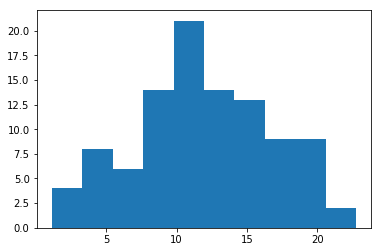

```python
plt.hist(D1)
plt.show()
```

##### a) Obtain the MLE parameters assuming the model is a normal distribution.

```python
mean = mean(D1)
stdv = stdv(D1, mean)

theta = [mean, stdv]

li_D1_normal = likelihood_normal(theta, D1)
```

##### b) Obtain the MLE parameters assuming the model is a uniform distribution.

A *Probability Density Function* (PDF) da distribuição Uniforme é dada por:

$$ f(\mathcal{D} , \theta) = \frac{1}{\theta} = \theta^{-1} $$

Onde os valores do *Dataset* devem ser superiores a 0 e inferiores a $ \theta $. Portanto, os parâmetros para a distribuição devem ser o **menor** e **maior** valor do conjunto de dados. E a função *Likelihood* é dada pelo produtório entre eles: $$ \mathcal{L}(\theta , \mathcal{D}) = \prod_{i = 1}^{n} \theta^{-1} = \theta^{-n} $$

Que pode ser representada pela função em Python:

```python
def likelihood_uniform(theta, dataset):
    return (theta[1] - theta[0]) ** - len(dataset)

theta = [min(D1), max(D1)]

li_D1_uniform = likelihood_uniform(theta, D1)
```

#### 2. Consider dataset D2

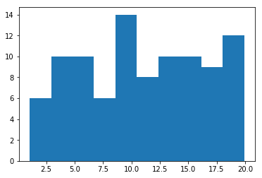

```python
plt.hist(D2)
plt.show()
```

##### a) Obtain the MLE parameters assuming the model is a normal distribution.

```python
mean = mean(D2)
stdv = stdv(D2, mean)

theta = [mean, stdv]

li_D2_normal = likelihood_normal(theta, D2)
```

##### b) Obtain the MLE parameters assuming the model is a uniform distribution.

```python
theta = [max(D2), min(D2)]

li_D2_uniform = likelihood_uniform(theta, D2)
```

#### 3. Using what you learned about the *likelihood*, which of the two datasets was generated by a normal distribution, and which one was generated by a uniform distribution. Comment your answer and indicate how sure are you concerning your answer.

```python
D1_ratio = li_D1_uniform / li_D1_normal
D2_ratio = li_D2_uniform / li_D2_normal

print('Para o Dataset 1, a distribuição Normal é {}x em relação a Uniforme'.format(D1_ratio))
print('Para o Dataset 2, a distribuição Normal é {}x em relação a Uniforme'.format(D2_ratio))
```

```
Para o Dataset 1, a distribuição Normal é 8.806811404648603e-06x em relação a Uniforme
Para o Dataset 2, a distribuição Normal é -835750.9346326572x em relação a Uniforme
```

Logo podemos conclui que:

- D1 foi gerado por uma *Distribuição Normal*
- D2 foi gerado por uma *Distribuição Uniforme*

## Questão 3

> Para exemplificar a aplicação de regressão linear, utilizaremos um pequeno subconjunto de dados reais de [vendas de imóveis em Iowa](https://www.kaggle.com/c/house-prices-advanced-regression-techniques). Consideraremos apenas 1 *feature*, a área da casa vendida. O *target* a ser estimado é o preço de venda. A Tabela 1 possui 6 pontos obtidos a partir deste dataset. A Tabela 2 possui 2 pontos para os quais se deseja prever o valor de venda.

[figure not shown]

```python
tabela1_area  = [334  ,   438,   520,   605,    672,    767]
tabela1_preco = [39300, 60000, 68500, 86000, 113000, 133000]

tabela2_area  = [848, 912]
```

#### 1. Obtenha a partir dos dados da Tabela 1 os modelos *M1* e *M2* utilizando a técnica de regressção linear. Para o modelo *M1* utilize φ1 = [1, x]. Para o modelo *M2*, utilize φ2 = [1, x, x², x³, x^4].

```python
import numpy as np

def phi1(x): return [1, x]
def phi2(x): return [1, x, x ** 2, x ** 3, x ** 4]

def inputs(vector, model):
    new = []
    if model == 1:
        for x in vector:
            new.append(phi1(x))
    elif model == 2:
        for x in vector:
            new.append(phi2(x))
    else: new = None
    return np.array(new)

def weights(X, y):
    return np.dot(np.float_power(np.dot(np.transpose(X), X), -1), np.dot(np.transpose(X), y))

def model(X, w):
    return np.dot(X, w)
```

#### 2. Utilizando os modelos obtidos na questão anterior, calcule o erro quadrático médio para *M1* e *M2* considerando apenas os dados da Tabela 1. Calcule também a razão entre o erro quadrático médio de *M1* e *M2*.

```python
def mean_squared_error(predict, y):
    total_error = 0
    for i in range(len(y)):
        total_error += ((predict[i] - y[i]) ** 2)
    return total_error / len(y)

M1_input   = inputs(tabela1_area, 1)
M1_weights = weights(M1_input, tabela1_preco)
M1_predict = model(M1_input, M1_weights)
M1_error   = mean_squared_error(M1_predict, tabela1_preco)

M2_input   = inputs(tabela1_area, 2)
M2_weights = weights(M2_input, tabela1_preco)
M2_predict = model(M2_input, M2_weights)
M2_error   = mean_squared_error(M2_predict, tabela1_preco)

print('Erro Quadrático Médio de M1:', M1_error)
print('Erro Quadrático Médio de M2:', M2_error)
```

```
Erro Quadrático Médio de M1: 67987115556.2
Erro Quadrático Médio de M2: 4.51974619605e+20
```

#### 3. Calcule o valor estimado para y1 e y2 utilizando *M1* e *M2*.

```python
tabela2_area = [848, 912]

M1_input_tab2   = inputs(tabela2_area, 1)
M1_predict_tab2 = model(M1_input_tab2, M1_weights)

M2_input_tab2   = inputs(tabela2_area, 2)
M2_predict_tab2 = model(M2_input_tab2, M2_weights)

print('M1: y1 =', M1_predict_tab2[0], 'e y2 =', M1_predict_tab2[1])
print('M2: y1 =', M2_predict_tab2[0], 'e y2 =', M2_predict_tab2[1])
```

```
M1: y1 = 432422.859944 e y2 = 451871.542374
M2: y1 = 62407239915.4 e y2 = 83487201783.1
```

#### 4. Descobre-se que y1 = 155900 e y2 = 156000. A partir desta informação calcule o erro quadrático médio para *M1* e *M2*, considerando apenas os dados da Tabela 2. Calcule também a razão entre o erro quadrático médio de *M1* e *M2*. Houve mudança significativa na razão? Explique o resultado obtido.

```python
y_real = [155900, 156000]

M1_error_tab2 = mean_squared_error(M1_predict_tab2, y_real)
M2_error_tab2 = mean_squared_error(M2_predict_tab2, y_real)

print('Erro Quadrático Médio de M1 da Tabela 2:', M1_error_tab2)
print('Erro Quadrático Médio de M2 da Tabela 2:', M2_error_tab2)

ratio = M2_error_tab2 / M1_error_tab2
print('\n O erro de M2 é', ratio, 'vezes maior que o de M1')
```

```
Erro Quadrático Médio de M1 da Tabela 2: 82002430829.0
Erro Quadrático Médio de M2 da Tabela 2: 5.43236547445e+21

 O erro de M2 é 66246395619.4 vezes maior que o de M1
```

## Questão 4

> O objetivo deste problema é estudar *logistic regression*. Considere o [dataset da questão 3](https://www.kaggle.com/c/house-prices-advanced-regression-techniques). Considere apenas 1 *feature*, a área da casa vendida. O objetivo é calcular a probabilidade do preço ser superior a **dado valor** *T* a partir da área do imóvel. Importante: escolha um valor para *T* que seja do seu interesse a partir dos dados.

```python
import pandas as pd # Biblioteca para importar CSV

imoveis_train = pd.read_csv('./data-sets/Iowa/train.csv')[['LotArea','SalePrice']] # Dados de Treinamento
imoveis_test  = pd.read_csv('./data-sets/Iowa/test.csv')['LotArea'] # Dados de Teste
imoveis_train.head() # Exibindo os 5 primeiros itens do Dataset de Treinamento
```

[output not shown]

#### 1. A partir da função *sigmoid* mostre como obter o log likelihood para uma amostra de tamanho *N*.

#### 2. Como se acha os parâmetros do problema?

#### 3. A partir dos dados do site acima, usando **wT x** = [w0, w1x] ache a função sigm(wT x). Plote essa função.

#### 4. Para o valor de *T* escolhido, escolha um determinado valor de área e ache a probabilidade do preço ser maior que *T*.

## Questão 5

> Nesta questão será exemplificada a utilização de **Naive Bayes** para a anáise de sentimentos. Considere um *dataset* com avaliações de filmes obtidos a partir do site [*Rotten Tomatoes*](https://www.kaggle.com/c/sentiment-analysis-on-movie-reviews). Cada avaliação feita por um usuário é composta de um comentário e uma nota para o filme. Para simplificar o problema, consideramos um subconjunto deste *dataset* e associamos 2 classes a cada frase: análises positivas e análises negativas.

> Cada frase é representada por um vetor de *features* binárias conhecido como *bag of words*. Nesta representação, para cada frase a *feature* possui valor 1 se uma determinada palavra é utilizada na frase e valor 0 caso contrário. Consideraremos apenas 6 palavras neste exemplo: *good, funny, love, bad, dull, worst*. A tabela 3 mostra o número de vezes em que cada palavra apareceu em frases de análises positivas. A Tabela 4 mostra o número de vezes em que cada palavra apareceu em frases de análises negativas. A Tabela 5 mostra o número de frases com análises positivas e negativas presentes no dataset.

[figure not shown]

#### 1. Obtenha a partir dos dados presentes nas tabelas 3, 4 e 5 os parâmetros $ \pi c $ e $ \theta_{c, j} $.

#### 2. A Tabela 6 possui 3 frases cujo sentimento é desconhecido. Classifique utilizando o modelo calculado anteriormente se a análise é positiva ou negativa em cada uma das frases. Comente os resultados.

[figure not shown]

#### 3. Considere que mais dados sobre análises positivas foram coletados, enquanto os dados sobre análises negativas não sofreram alterações. As tabelas 7 e 8 mostram as mudanças obtidas a partir dos novos dados coletados. Recalcule o modelo e reclassifique as frases da Tabela 6. Houve mudança na classificação? Comente os resultados.

[figure not shown]

## Questão 6

#### 1. Write the expression for the probability mass function $(\mathcal{P}(x;\theta))$ of a mixture of 2 Gaussian distributions.

#### 2. Can you obtain closed form expressions for the MLE for this mixture distribution? Explain the cases where it is possible to obtain a closed for expression for the MLE and those where it is not possible.

#### 3. Describe the steps taken by the EM algorithm when expressions for the MLE for the mixture of 2 Gaussians can not be obtained.

#### 4. Use the dataset `data-EM.txt` and show the results for *3 steps* of the EM algorithm, assuming the model is a mixture of 2 Gaussians.